# Lung cancer survival analysis

Bortolussi Lorenzo, Cartago Marco, Tonet Lorenzo

2025-07-02

# NCCTG Lung Cancer Data

## Dataset description

The dataset we chose to analyze is the `cancer` dataset from the r package `survival`. The dataset itself was first collected and analyzed by the North Central Cancer Treatment Group. In this prospective study, participants were provided with a questionnaire prior to hospitalization. Each patient was also evaluated by a physician, who assigned a performance score based on their clinical condition.

The variables collected are the following:

| inst | The code of the institution in which the patient was hospitalized |
| --- | --- |
| time | The survival time in days |
| status | The censoring status |
| age | The age in years |
| sex | Patient sex |
| ph.ecog | ECOG performance score as rated by the physician. 0=asymptomatic, 1= symptomatic but completely ambulatory, 2= in bed <50% of the day, 3= in bed > 50% of the day but not bedbound, 4 = bedbound |
| ph.karno | Karnofsky performance score (bad=0-good=100) rated by physician |
| pat.karno | Karnofsky performance score as rated by the patient itself |
| meal.cal | Calories consumed at the meal before hospitalization |
| wt.loss | Weight loss in pounds in the last six months |

```r
data = survival::cancer
original_data = data
```

```r
summary(data)
```

```
##       inst            time            status           age
##  Min.   : 1.00   Min.   :   5.0   Min.   :1.000   Min.   :39.00
##  1st Qu.: 3.00   1st Qu.: 166.8   1st Qu.:1.000   1st Qu.:56.00
##  Median :11.00   Median : 255.5   Median :2.000   Median :63.00
##  Mean   :11.09   Mean   : 305.2   Mean   :1.724   Mean   :62.45
##  3rd Qu.:16.00   3rd Qu.: 396.5   3rd Qu.:2.000   3rd Qu.:69.00
##  Max.   :33.00   Max.   :1022.0   Max.   :2.000   Max.   :82.00
##  NA's   :1
##       sex           ph.ecog          ph.karno        pat.karno
##  Min.   :1.000   Min.   :0.0000   Min.   : 50.00   Min.   : 30.00
##  1st Qu.:1.000   1st Qu.:0.0000   1st Qu.: 75.00   1st Qu.: 70.00
##  Median :1.000   Median :1.0000   Median : 80.00   Median : 80.00
##  Mean   :1.395   Mean   :0.9515   Mean   : 81.94   Mean   : 79.96
##  3rd Qu.:2.000   3rd Qu.:1.0000   3rd Qu.: 90.00   3rd Qu.: 90.00
##  Max.   :2.000   Max.   :3.0000   Max.   :100.00   Max.   :100.00
##                  NA's   :1        NA's   :1        NA's   :3
##     meal.cal         wt.loss
##  Min.   :  96.0   Min.   :-24.000
##  1st Qu.: 635.0   1st Qu.:  0.000
##  Median : 975.0   Median :  7.000
##  Mean   : 928.8   Mean   :  9.832
##  3rd Qu.:1150.0   3rd Qu.: 15.750
##  Max.   :2600.0   Max.   : 68.000
##  NA's   :47       NA's   :14
```

```r
data$age.cat <- cut(
    data$age,
    breaks=c(0, 50, 70, Inf),
    labels=c("<50", "50-70", "70+")
)
```

## NAs

We first tried to see wether there is any systematic distribution of missing values inside the dataset. The first thing we did is a comprehensive NA plot for all the variables.

We then tried to stratify with respect to the different categorical variables, so to check if there was any substantial difference in the NA distribution.

Most of the missing values, around 20% of the total, are in the variable `meal.cal`. So for some initial data analysis we decided to ignore this variable

```r
colSums(is.na(data))
```

```
##      inst      time    status       age       sex   ph.ecog  ph.karno pat.karno
##         1         0         0         0         0         1         1         3
##  meal.cal   wt.loss   age.cat
##        47        14         0
```

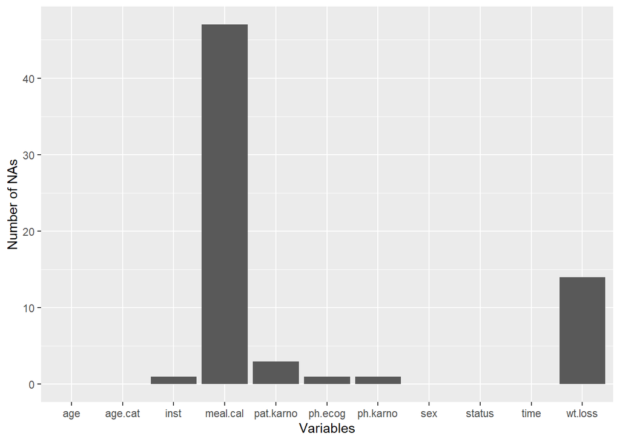

```r
nas <- data.frame(var=colnames(data), na=colSums(is.na(data)))
ggplot(nas, aes(x=var, y=na))+
  geom_bar(stat="identity")+
  xlab("Variables") +
  ylab("Number of NAs") +
  theme_grey()
```

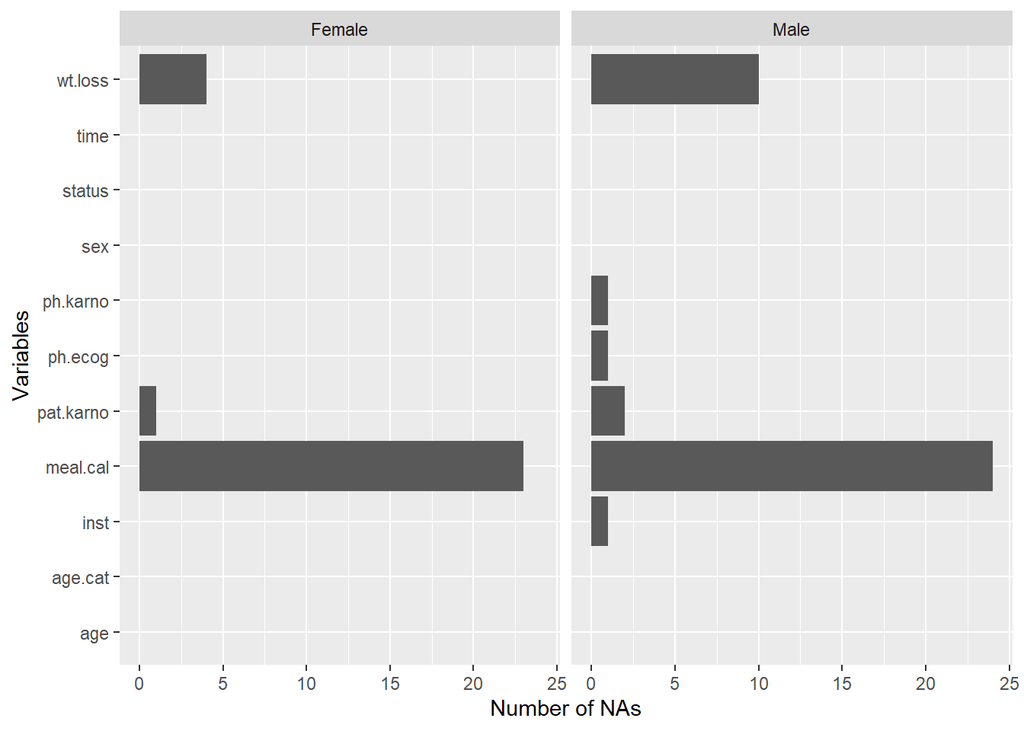

```r
dataM <-data.frame(
  var=colnames(data[data$sex=="1",]),
  sex="Male",
  na=colSums(is.na(data[data$sex=="1",]))
)

dataF <- data.frame(
  var=colnames(data[data$sex=="2",]),
  sex="Female",
  na=colSums(is.na(data[data$sex=="2",]))
)

nas_conditioned <- rbind(dataM, dataF)
nas_conditioned_df <- data.frame(var=colnames(data), na=colSums(is.na(data)))

ggplot(nas_conditioned, aes(x=var, y=na))+
  xlab("Variables") +
  ylab("Number of NAs") +
  geom_bar(stat="identity")+
  facet_wrap(~sex) +
  coord_flip()
```

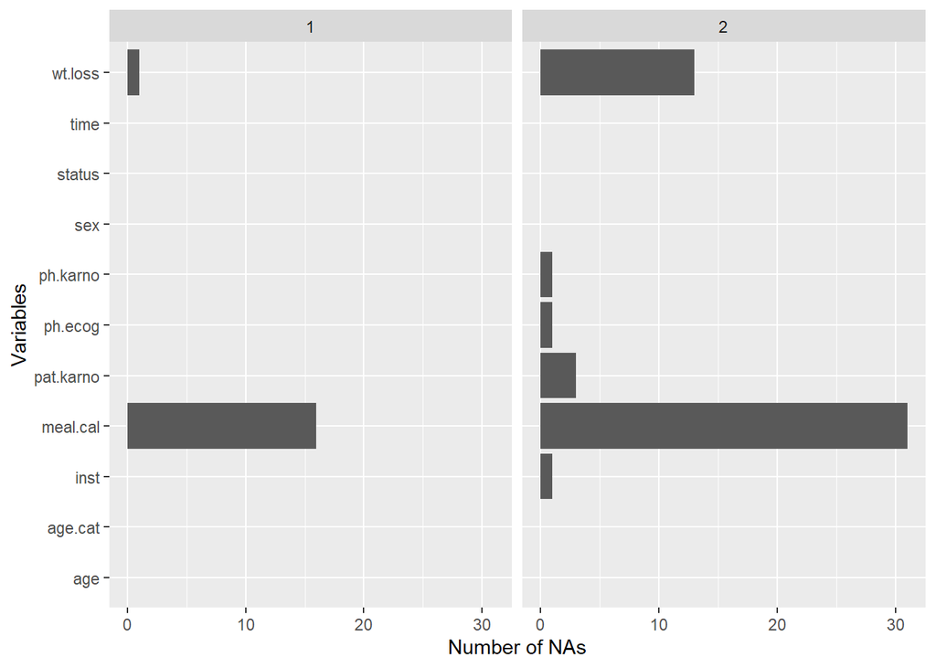

```r
data1 <-data.frame(
  var=colnames(data[data$status=="1",]),
  status="1",
  na=colSums(is.na(data[data$status=="1",]))
)

data2 <- data.frame(
  var=colnames(data[data$status=="2",]),
  status="2",
  na=colSums(is.na(data[data$status=="2",]))
)


nass <- rbind(data1, data2)
nas <- data.frame(var=colnames(data), na=colSums(is.na(data)))

ggplot(nass, aes(x=var, y=na))+
  xlab("Variables") +
  ylab("Number of NAs") +
  geom_bar(stat="identity")+
  facet_wrap(~status) +
  coord_flip()
```

```r
hasna <- as.numeric(rowSums(is.na(data)) > 0)
na.corr.data <- cbind(data, hasna)
na.corr.data <- na.corr.data[-9]

m <- glm(
  hasna ~ inst + ph.ecog + ph.karno + pat.karno + sex + time,
  family = binomial(link="logit"),
  data=na.corr.data
)
```

## Exploratory data analysis

### Univariate analysis

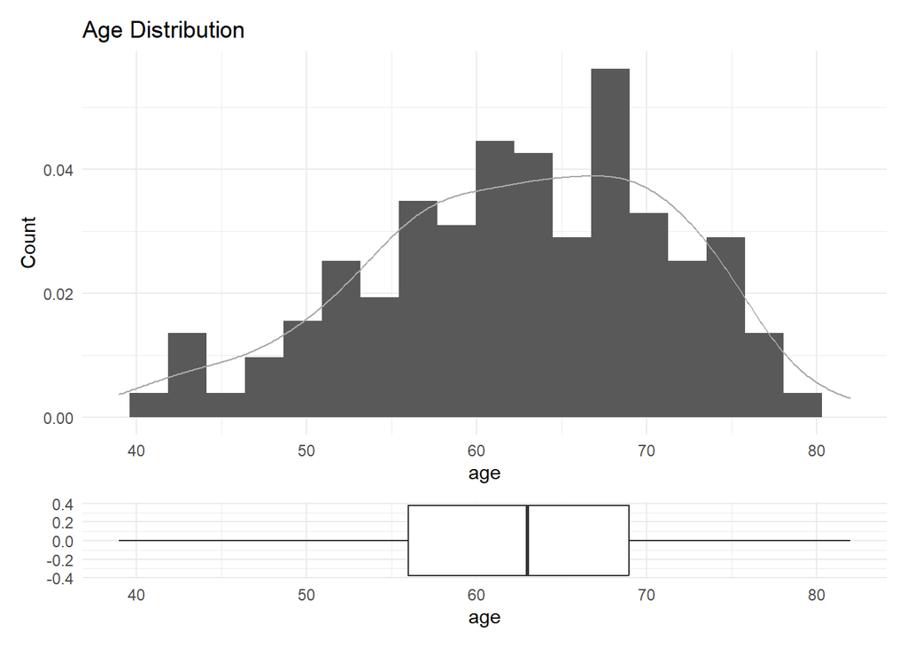

```r
x_limits <- range(data$age)

p1 = ggplot(data = data, aes(x = age, y = after_stat(density))) +
  geom_histogram(bins = 20) +
  geom_density(alpha = 0.5, colour="darkgray") +
  labs(title = "Age Distribution", y = "Count") +
  scale_x_continuous(limits = x_limits) +
  theme_minimal()

p2 = ggplot(data = data, aes(x = age)) +
  geom_boxplot() +
  labs(x = "age") +
  scale_x_continuous(limits = x_limits) +
  theme_minimal()

p1 + p2 + plot_layout(heights = c(5,1))
```

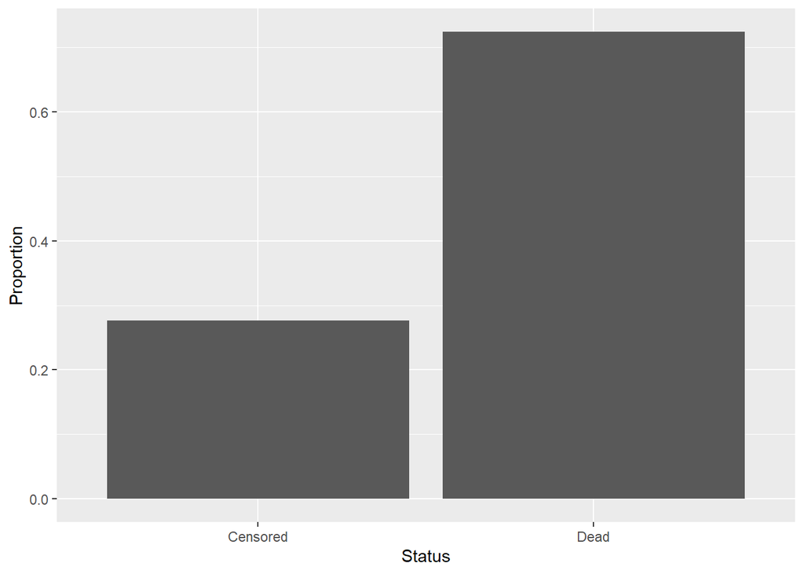

```r
ggplot(data, aes(x=status))+
  geom_bar(aes(y = after_stat(prop), group = 1)) +
  scale_x_discrete(labels = c("1" = "Censored", "2" = "Dead")) +
  labs(x = "Status", y = "Proportion") +
  theme_grey()
```

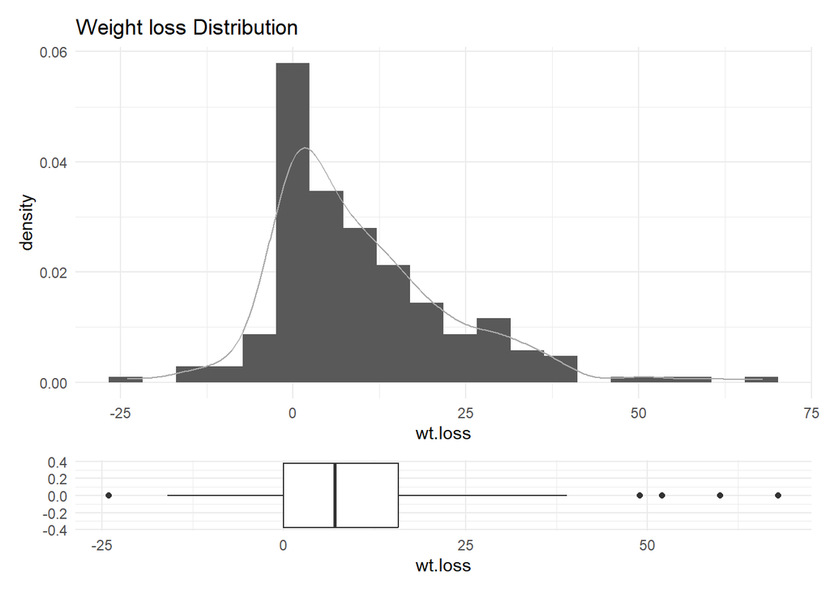

```r
x_limits <- range(data$wt.loss)

p1 = ggplot(data = data, aes(x = wt.loss, y = after_stat(density))) +
  geom_histogram(bins = 20) +
  geom_density(alpha = 0.5, colour="darkgray") +
  labs(title = "Weight loss Distribution") +
  scale_x_continuous(limits = x_limits) +
  theme_minimal()

p2 = ggplot(data = data, aes(x = wt.loss)) +
  geom_boxplot() +
  labs(x = "wt.loss") +
  scale_x_continuous(limits = x_limits) +
  theme_minimal()

p1 + p2 + plot_layout(heights = c(5,1))
```

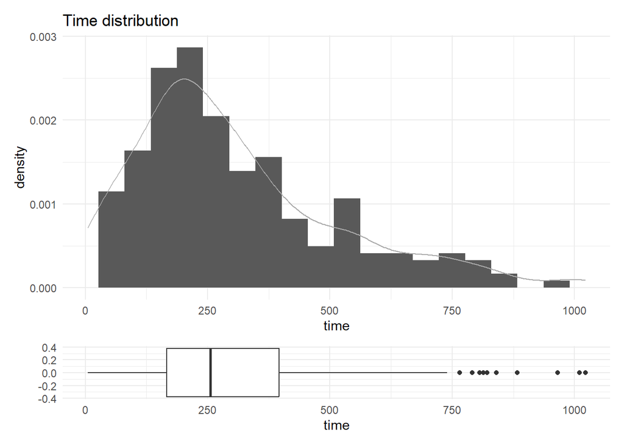

```r
x_limits <- range(data$time)

p1 = ggplot(data = data, aes(x = time, y = after_stat(density))) +
  geom_histogram(bins = 20) +
  geom_density(alpha = 0.5, colour="darkgray") +
  labs(title = "Time distribution") +
  scale_x_continuous(limits = x_limits) +
  theme_minimal()

p2 = ggplot(data = data, aes(x = time)) +
  geom_boxplot() +
  labs(x = "time") +
  scale_x_continuous(limits = x_limits) +
  theme_minimal()

p1 + p2 + plot_layout(heights = c(5,1))
```

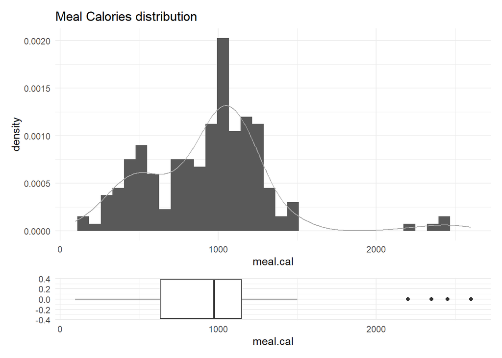

```r
x_limits <- range(data$meal.cal, na.rm = TRUE)

p1 = ggplot(data = data, aes(x = meal.cal, y = after_stat(density))) +
  geom_histogram(bins = 35) +
  geom_density(alpha = 0.5, colour="darkgray") +
  labs(title = "Meal Calories distribution") +
  scale_x_continuous(limits = x_limits) +
  theme_minimal()

p2 = ggplot(data = data, aes(x = meal.cal)) +
  geom_boxplot() +
  labs(x = "meal.cal") +
  scale_x_continuous(limits = x_limits) +
  theme_minimal()

p1 + p2 + plot_layout(heights = c(5,1))
```

### Bivariate analysis

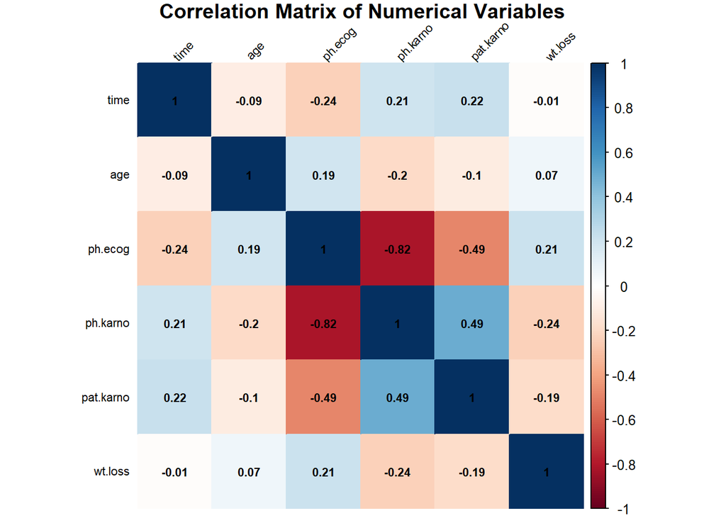

```r
ds = subset(original_data, select=c(time, age, ph.ecog, ph.karno, pat.karno, wt.loss))
corr.mat <- cor(ds, use="pairwise.complete.obs", method="spearman")

corrplot(corr.mat, method="color", type="full", tl.col="black", tl.srt=45,
         addCoef.col="black", number.cex=0.7, tl.cex=0.7,
         title="Correlation Matrix of Numerical Variables", mar=c(0,0,1,0))
```

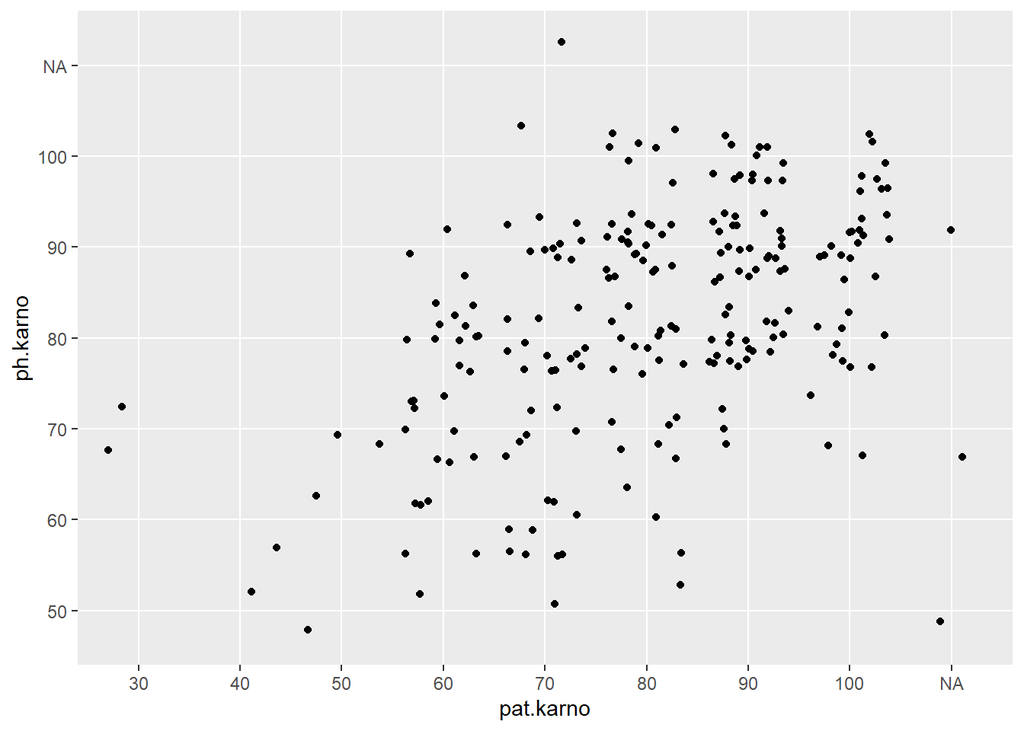

```r
ggplot(data, aes(x=pat.karno, y=ph.karno)) +
  geom_jitter()
```

### Conditioning to status

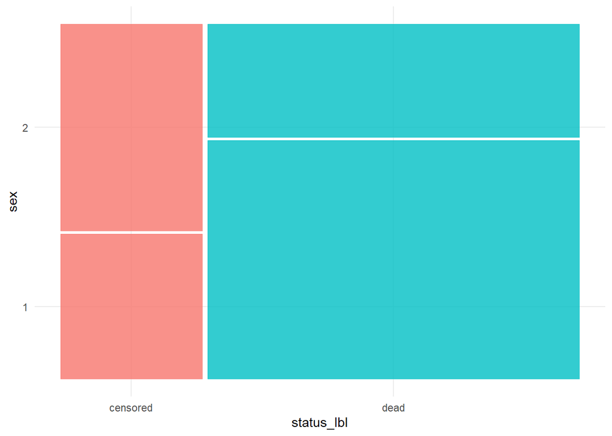

```r
tab = prop.table(table(data$status, data$sex))
df_tab = as.data.frame(tab)
colnames(df_tab) = c("status", "sex", "prop")

data %>%
  mutate(status_lbl = factor(status, levels = c(1, 2), labels = c("censored", "dead"))) %>%
  ggplot() +
  geom_mosaic(aes(x = product(sex, status_lbl), fill = status_lbl)) +
  scale_fill_discrete(guide = "none") +
  theme_minimal()
```

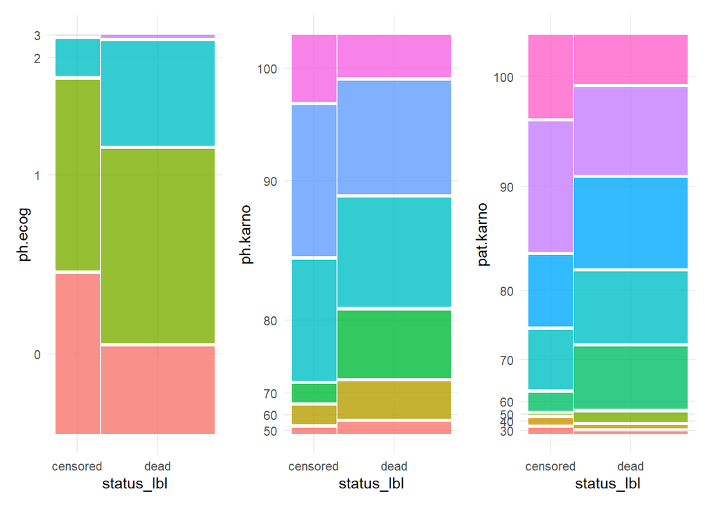

```r
p1 <- data %>%
  mutate(status_lbl = factor(status, levels = c(1, 2), labels = c("censored", "dead"))) %>%
  ggplot() +
  geom_mosaic(aes(x = product(ph.ecog, status_lbl), fill = ph.ecog), na.rm = TRUE) +
  scale_fill_discrete(guide = "none") +
  theme_minimal()

p2 <- data %>%
  mutate(status_lbl = factor(status, levels = c(1, 2), labels = c("censored", "dead"))) %>%
  ggplot() +
  geom_mosaic(aes(x = product(ph.karno, status_lbl), fill = ph.karno), na.rm = TRUE) +
  scale_fill_discrete(guide = "none") +
  theme_minimal()

p3 <- data %>%
  mutate(status_lbl = factor(status, levels = c(1, 2), labels = c("censored", "dead"))) %>%
  ggplot() +
  geom_mosaic(aes(x = product(pat.karno, status_lbl), fill = pat.karno), na.rm = TRUE) +
  scale_fill_discrete(guide = "none") +
  theme_minimal()

p1 + p2 + p3 + plot_layout(ncol = 3)
```

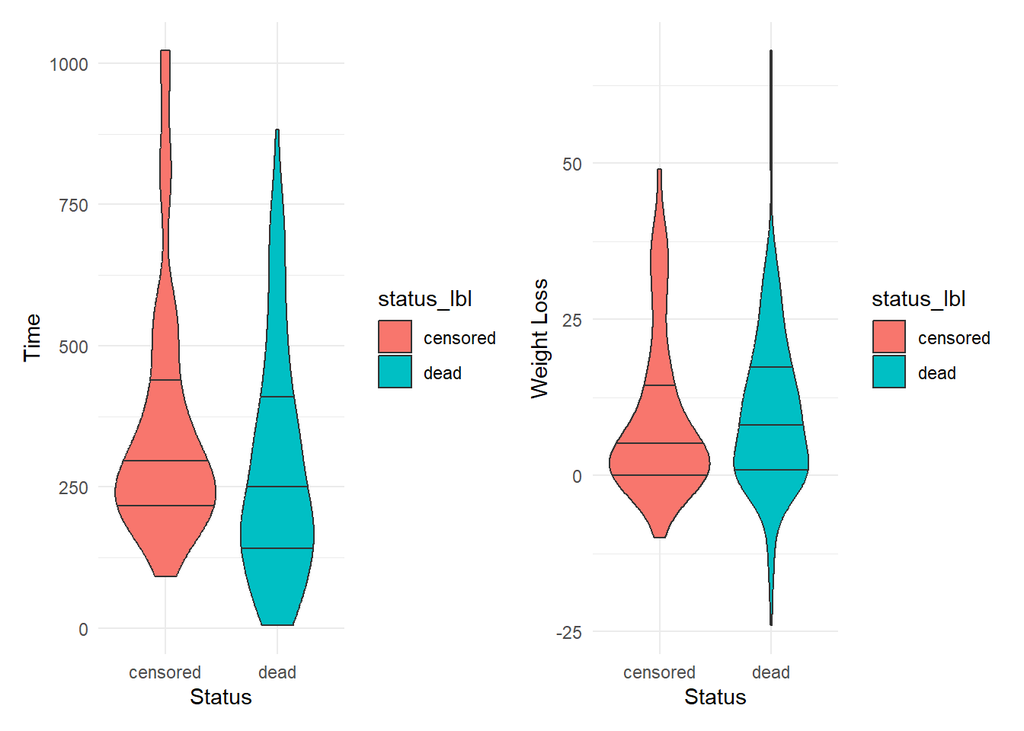

```r
p1 <- data %>%
  mutate(status_lbl = factor(status, levels = c(1, 2), labels = c("censored", "dead"))) %>%
  ggplot(aes(x = status_lbl, y = time, fill = status_lbl)) +
  geom_violin(draw_quantiles = c(0.25, 0.5, 0.75)) +
  labs(x = "Status", y = "Time") +
  theme_minimal()

p2 <- data %>%
  mutate(status_lbl = factor(status, levels = c(1, 2), labels = c("censored", "dead"))) %>%
  ggplot(aes(x = status_lbl, y = wt.loss, fill = status_lbl)) +
  geom_violin(draw_quantiles = c(0.25, 0.5, 0.75)) +
  labs(x = "Status", y = "Weight Loss") +
  theme_minimal()

p1 + p2 + plot_layout(ncol = 2)
```

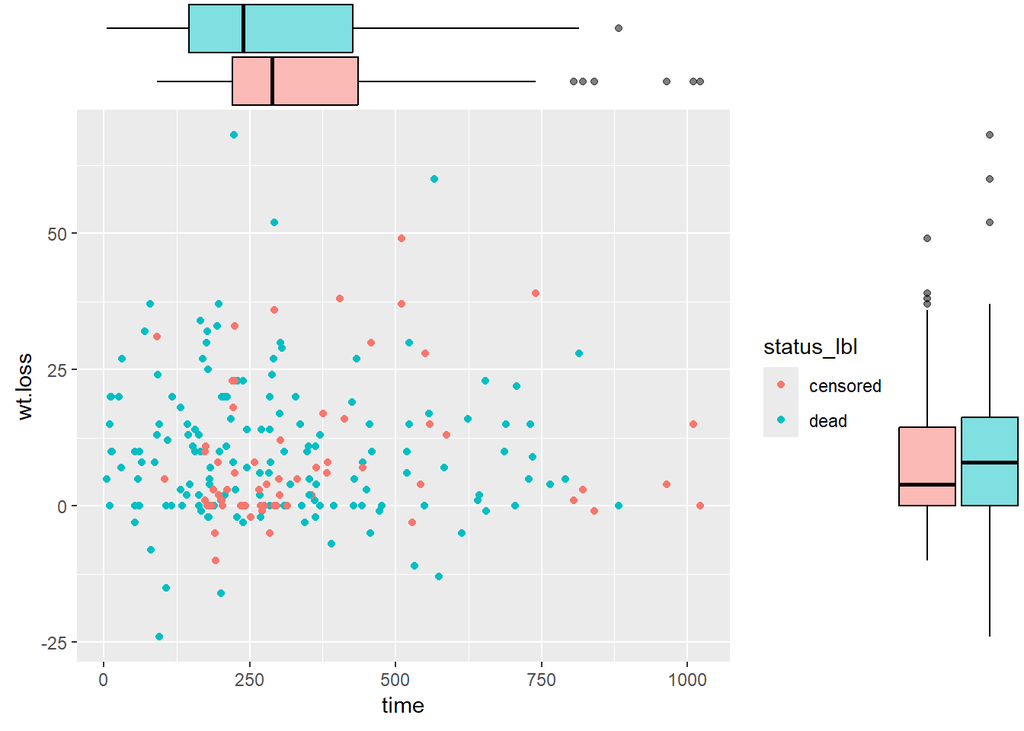

```r
p <- data %>%
  mutate(status_lbl = factor(status, levels = c(1, 2), labels = c("censored", "dead"))) %>%
  ggplot(aes(x = time, y = wt.loss, color = status_lbl)) +
  geom_point()

p1 = ggMarginal(p, groupFill = T, type="boxplot")
p1
```

```r
data2 <- survival::cancer
data2 <- subset(data2, select = -meal.cal)
data2 <- drop_na(data2)
data2$sex <- factor(data2$sex)
levels(data2$sex) <- c("M", "F")
data2$status <- as.numeric(as.character(data2$status)) - 1
data2$ph.ecog <- factor(data2$ph.ecog)
data2$ph.karno <- factor(data2$ph.karno)
data2$pat.karno <- factor(data2$pat.karno)
data.cl <- data2

rm(data2)
```

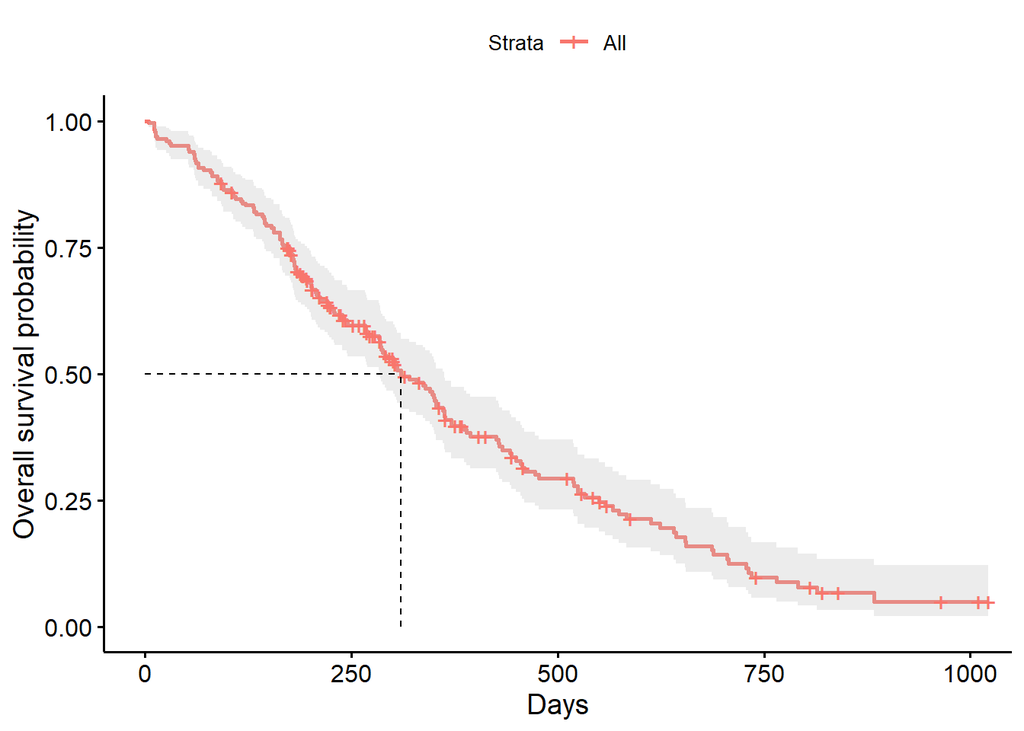

```r
survfit_sex = survfit(Surv(time, status) ~ 1, data=original_data)

ggsurvplot(survfit_sex,
           xlab="Days",
           ylab="Overall survival probability",
           risk.table=F,
           conf.int=TRUE,
           surv.median.line="hv",
           data=original_data)
```

```r
original_data$age.cat <- cut(original_data$age, breaks=c(0, 50, 70, 100), labels=c("<50", "50-70", "70+"))

survfit_ecog = survfit(Surv(time, event=status) ~ age.cat, data=original_data)
summary(survfit_ecog)
```

```
## Call: survfit(formula = Surv(time, event = status) ~ age.cat, data = original_data)
##
##                 age.cat=<50
##  time n.risk n.event survival std.err lower 95% CI upper 95% CI
##    81     26       1    0.962  0.0377       0.8904        1.000
##    92     25       1    0.923  0.0523       0.8261        1.000
##   131     24       1    0.885  0.0627       0.7700        1.000
##   132     23       1    0.846  0.0708       0.7182        0.997
##   167     22       1    0.808  0.0773       0.6696        0.974
##   181     21       1    0.769  0.0826       0.6232        0.949
##   212     16       1    0.721  0.0904       0.5641        0.922
##   223     15       1    0.673  0.0963       0.5085        0.891
##   239     14       1    0.625  0.1007       0.4558        0.857
##   268     13       1    0.577  0.1038       0.4055        0.821
##   305     11       1    0.524  0.1068       0.3519        0.782
```

[output cut: 146 more lines]

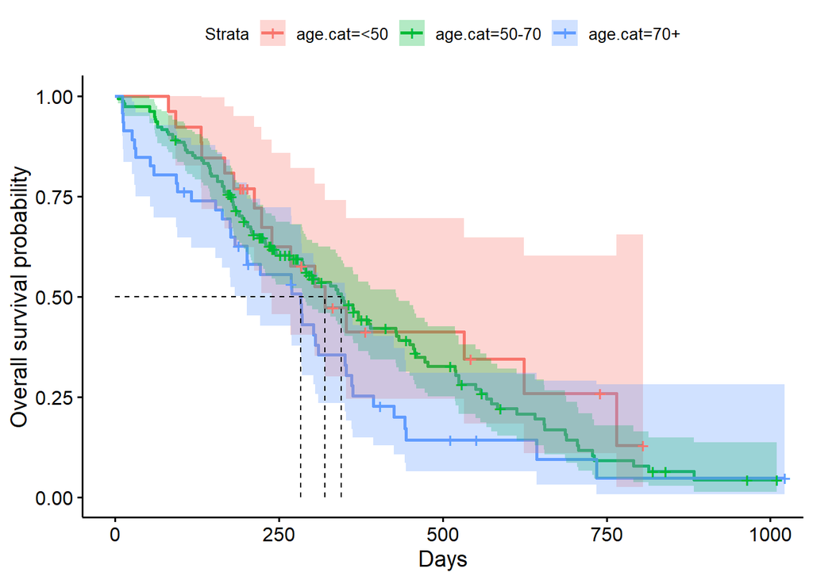

```r
ggsurvplot(survfit_ecog,
           xlab="Days",
           ylab="Overall survival probability",
           risk.table=FALSE,
           risk.table.height=0.25,
           conf.int=TRUE,
           surv.median.line="hv",
           data=original_data,
           break.x.by=250,  # Meno punti sull'asse x
           xlim=c(0,1000))
```

```r
survdiff(Surv(time, status) ~ sex, original_data)
```

```
## Call:
## survdiff(formula = Surv(time, status) ~ sex, data = original_data)
##
##         N Observed Expected (O-E)^2/E (O-E)^2/V
## sex=1 138      112     91.6      4.55      10.3
## sex=2  90       53     73.4      5.68      10.3
##
##  Chisq= 10.3  on 1 degrees of freedom, p= 0.001
```

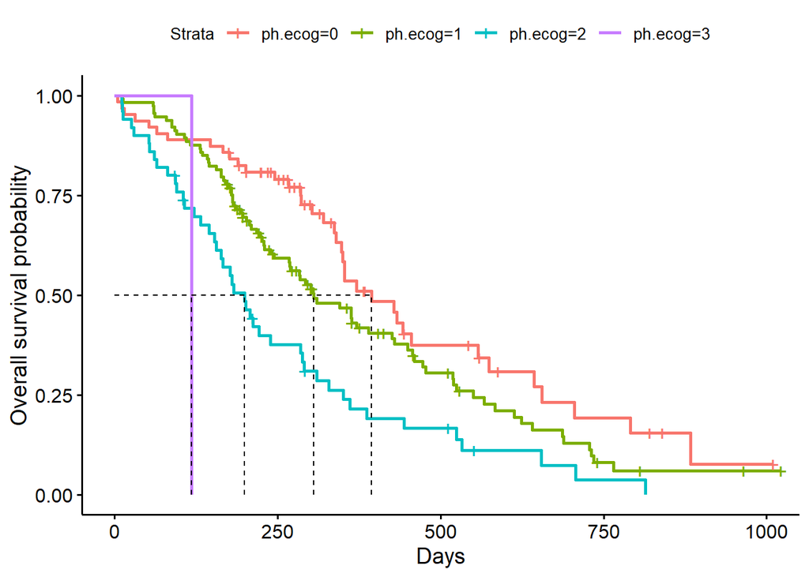

```r
survfit_ecog = survfit(Surv(time, event=status) ~ ph.ecog, data=original_data)
ggsurvplot(survfit_ecog,
           xlab="Days",
           ylab="Overall survival probability",
           risk.table=FALSE,
           conf.int=FALSE,
           surv.median.line="hv",
           data=original_data)
```

```r
survdiff(Surv(time, status) ~ ph.ecog, original_data)
```

```
## Call:
## survdiff(formula = Surv(time, status) ~ ph.ecog, data = original_data)
##
## n=227, 1 osservazione eliminata a causa di un valore mancante.
##
##             N Observed Expected (O-E)^2/E (O-E)^2/V
## ph.ecog=0  63       37   54.153    5.4331    8.2119
## ph.ecog=1 113       82   83.528    0.0279    0.0573
## ph.ecog=2  50       44   26.147   12.1893   14.6491
## ph.ecog=3   1        1    0.172    3.9733    4.0040
##
##  Chisq= 22  on 3 degrees of freedom, p= 7e-05
```

```r
cox_sex = coxph(Surv(time, status) ~ sex, data=data.cl)
print(cox_sex)
```

```
## Call:
## coxph(formula = Surv(time, status) ~ sex, data = data.cl)
##
##         coef exp(coef) se(coef)      z       p
## sexF -0.5303    0.5884   0.1764 -3.006 0.00264
##
## Likelihood ratio test=9.51  on 1 df, p=0.002048
## n= 209, number of events= 147
```

```r
test.ph = cox.zph(cox_sex)
print(test.ph)
```

```
##        chisq df    p
## sex     2.61  1 0.11
## GLOBAL  2.61  1 0.11
```

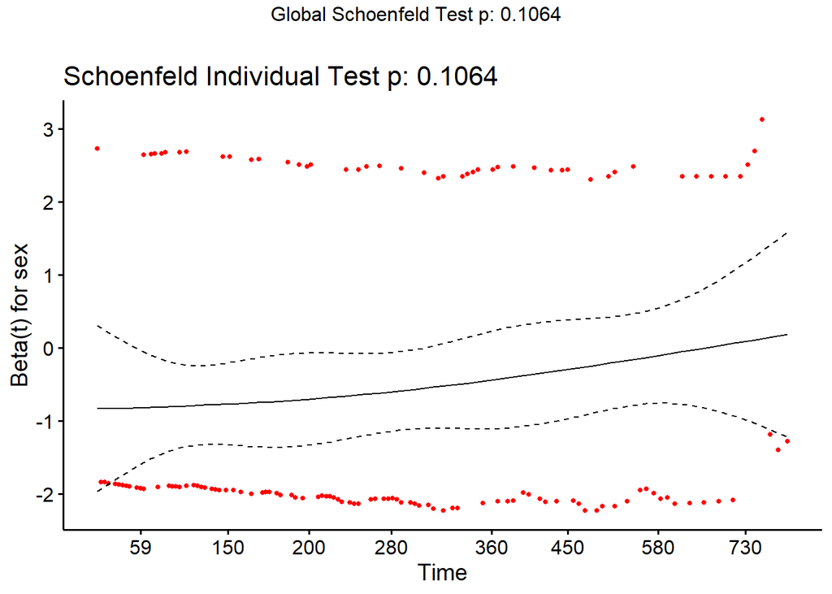

```r
ggcoxzph(test.ph)
```

```r
cox_age_sex = coxph(Surv(time, status) ~ age+sex, data=data.cl)
print(cox_age_sex)
```

```
## Call:
## coxph(formula = Surv(time, status) ~ age + sex, data = data.cl)
##
##           coef exp(coef)  se(coef)      z       p
## age   0.018890  1.019069  0.009771  1.933 0.05321
## sexF -0.511689  0.599482  0.176629 -2.897 0.00377
##
## Likelihood ratio test=13.33  on 2 df, p=0.001272
## n= 209, number of events= 147
```

```r
test.ph = cox.zph(cox_age_sex)
print(test.ph)
```

```
##        chisq df    p
## age    0.311  1 0.58
## sex    2.351  1 0.13
## GLOBAL 2.610  2 0.27
```

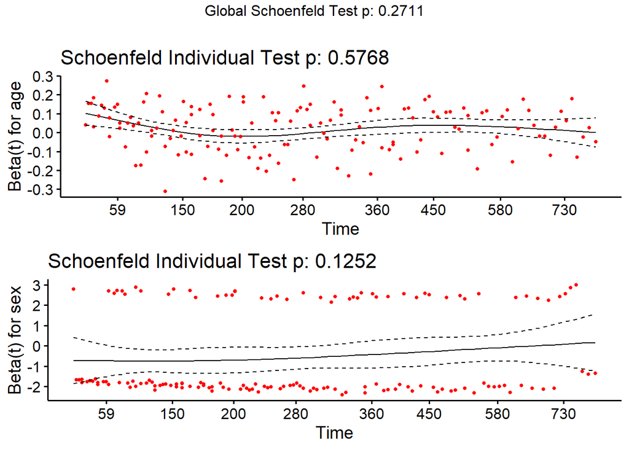

```r
ggcoxzph(test.ph)
```

### Karno “models”

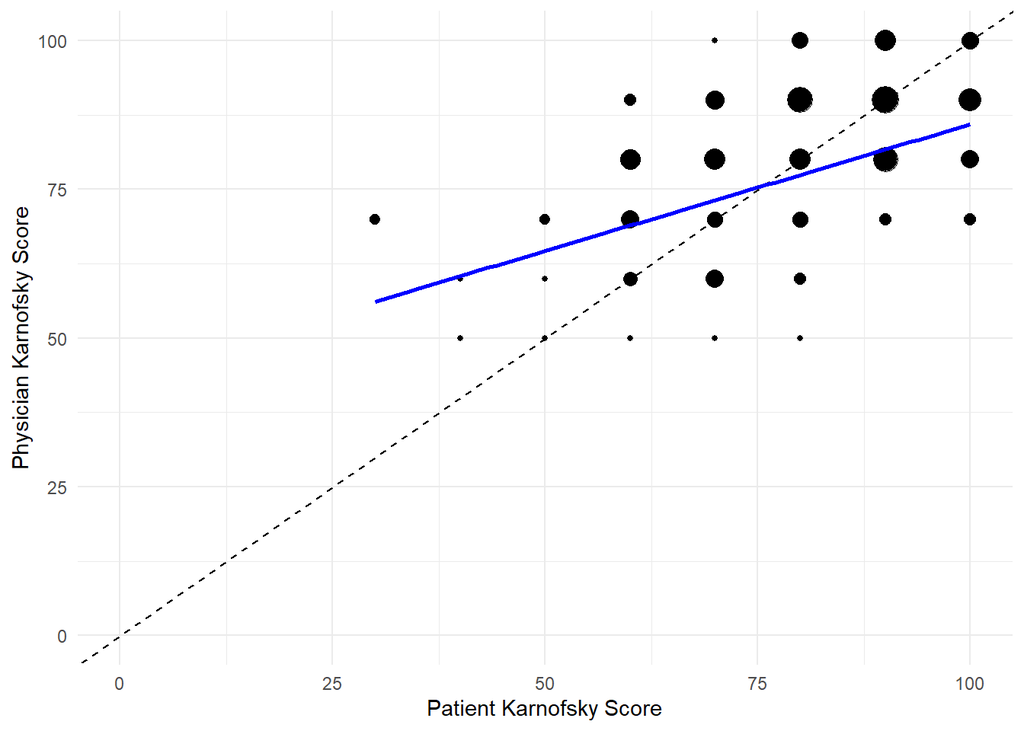

```r
axis_limits = c(0, 100)

bubble_data = original_data %>%
  count(pat.karno, ph.karno)

ggplot(bubble_data, aes(x=pat.karno, y=ph.karno, size = n)) +
  geom_point() +
  geom_abline(intercept = 0, slope = 1, linetype = "dashed") +
  geom_smooth(method="lm", se=FALSE, color="blue") +
  labs(x="Patient Karnofsky Score", y="Physician Karnofsky Score") +
  scale_x_continuous(limits=axis_limits) +
  scale_y_continuous(limits=axis_limits) +
  guides(size = "none") +
  theme_minimal()
```

```r
cox_karno = coxph(Surv(time, status) ~ pat.karno, data=data.cl)
print(cox_karno)
```

```
## Call:
## coxph(formula = Surv(time, status) ~ pat.karno, data = data.cl)
##
##                  coef exp(coef) se(coef)      z     p
## pat.karno40  -0.79712   0.45063  1.41943 -0.562 0.574
## pat.karno50   0.72197   2.05849  1.15910  0.623 0.533
## pat.karno60   0.07698   1.08002  1.02290  0.075 0.940
## pat.karno70  -0.43726   0.64580  1.02336 -0.427 0.669
## pat.karno80  -0.65501   0.51944  1.01991 -0.642 0.521
## pat.karno90  -0.81713   0.44170  1.01914 -0.802 0.423
## pat.karno100 -0.86409   0.42144  1.03257 -0.837 0.403
##
## Likelihood ratio test=16.84  on 7 df, p=0.01844
## n= 209, number of events= 147
```

```r
test.ph = cox.zph(cox_karno)
print(test.ph)
```

```
##           chisq df    p
## pat.karno   6.5  7 0.48
## GLOBAL      6.5  7 0.48
```

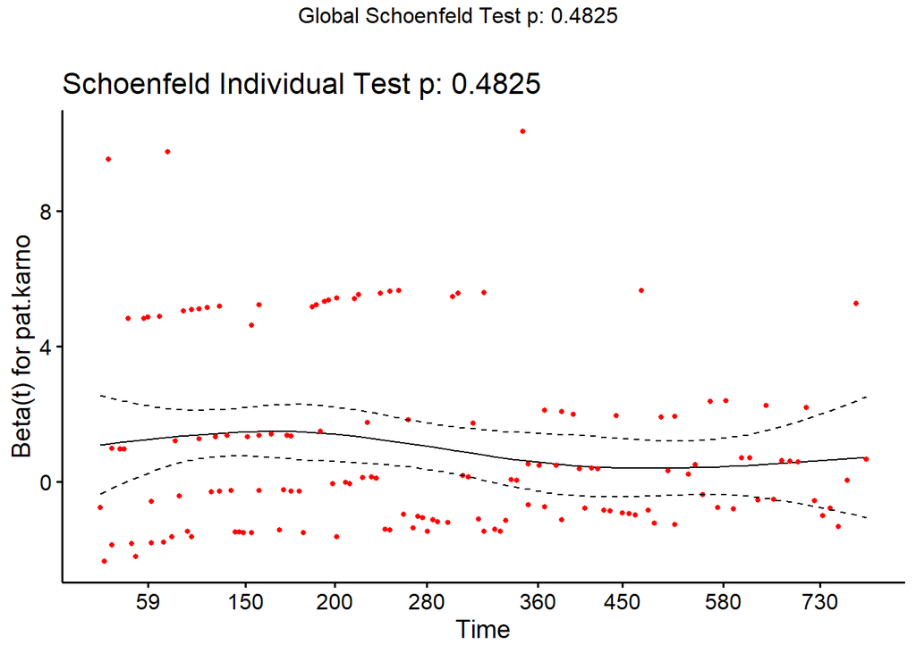

```r
ggcoxzph(test.ph)
```

```r
cox_ph.karno = coxph(Surv(time, status) ~ ph.karno, data=data.cl)
print(cox_ph.karno)
```

```
## Call:
## coxph(formula = Surv(time, status) ~ ph.karno, data = data.cl)
##
##               coef exp(coef) se(coef)     z     p
## ph.karno60  1.0395    2.8278   0.6471 1.606 0.108
## ph.karno70  0.9197    2.5086   0.6144 1.497 0.134
## ph.karno80  0.7025    2.0188   0.6063 1.159 0.247
## ph.karno90  0.3086    1.3615   0.6035 0.511 0.609
## ph.karno100 0.2442    1.2765   0.6291 0.388 0.698
##
## Likelihood ratio test=12.38  on 5 df, p=0.02995
## n= 209, number of events= 147
```

```r
test.ph = cox.zph(cox_ph.karno)
print(test.ph)
```

```
##          chisq df    p
## ph.karno  6.63  5 0.25
## GLOBAL    6.63  5 0.25
```

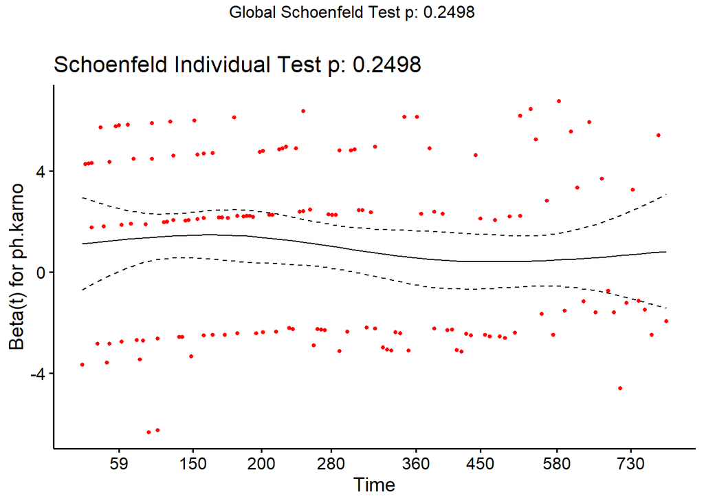

```r
ggcoxzph(test.ph)
```

```r
cox_karno = coxph(
  Surv(time, status) ~ age + sex + ph.ecog + ph.karno + wt.loss , data=data.cl)
summary(cox_karno)
```

```
## Call:
## coxph(formula = Surv(time, status) ~ age + sex + ph.ecog + ph.karno +
##     wt.loss, data = data.cl)
##
##   n= 209, number of events= 147
##
##                  coef exp(coef)  se(coef)      z Pr(>|z|)
## age          0.015317  1.015435  0.009910  1.546 0.122207
## sexF        -0.676261  0.508515  0.181047 -3.735 0.000188 ***
## ph.ecog1     0.503714  1.654857  0.295641  1.704 0.088417 .
## ph.ecog2     1.296884  3.657883  0.438916  2.955 0.003129 **
## ph.ecog3     2.522332 12.457615  1.139637  2.213 0.026879 *
## ph.karno60   1.073367  2.925211  0.666982  1.609 0.107553
## ph.karno70   1.231301  3.425683  0.626358  1.966 0.049321 *
## ph.karno80   1.541371  4.670991  0.632516  2.437 0.014814 *
## ph.karno90   1.283799  3.610330  0.645029  1.990 0.046558 *
## ph.karno100  1.361501  3.902046  0.715796  1.902 0.057161 .
## wt.loss     -0.012800  0.987281  0.007048 -1.816 0.069336 .
## ---
## Signif. codes:  0 '***' 0.001 '**' 0.01 '*' 0.05 '.' 0.1 ' ' 1
##
##             exp(coef) exp(-coef) lower .95 upper .95
## age            1.0154    0.98480    0.9959    1.0354
## sexF           0.5085    1.96651    0.3566    0.7251
## ph.ecog1       1.6549    0.60428    0.9271    2.9540
## ph.ecog2       3.6579    0.27338    1.5475    8.6464
## ph.ecog3      12.4576    0.08027    1.3347  116.2776
## ph.karno60     2.9252    0.34186    0.7914   10.8117
## ph.karno70     3.4257    0.29191    1.0037   11.6924
## ph.karno80     4.6710    0.21409    1.3521   16.1365
## ph.karno90     3.6103    0.27698    1.0198   12.7819
## ph.karno100    3.9020    0.25628    0.9594   15.8701
## wt.loss        0.9873    1.01288    0.9737    1.0010
##
## Concordance= 0.649  (se = 0.027 )
## Likelihood ratio test= 39.18  on 11 df,   p=5e-05
## Wald test            = 39.11  on 11 df,   p=5e-05
## Score (logrank) test = 41.82  on 11 df,   p=2e-05
```

```r
test.ph = cox.zph(cox_karno)
print(test.ph)
```

```
##            chisq df    p
## age       0.0679  1 0.79
## sex       1.7013  1 0.19
## ph.ecog   5.8682  3 0.12
## ph.karno  5.3288  5 0.38
## wt.loss   0.0998  1 0.75
## GLOBAL   12.0713 11 0.36
```

```r
print(cox_karno)
```

```
## Call:
## coxph(formula = Surv(time, status) ~ age + sex + ph.ecog + ph.karno +
##     wt.loss, data = data.cl)
##
##                  coef exp(coef)  se(coef)      z        p
## age          0.015317  1.015435  0.009910  1.546 0.122207
## sexF        -0.676261  0.508515  0.181047 -3.735 0.000188
## ph.ecog1     0.503714  1.654857  0.295641  1.704 0.088417
## ph.ecog2     1.296884  3.657883  0.438916  2.955 0.003129
## ph.ecog3     2.522332 12.457615  1.139637  2.213 0.026879
## ph.karno60   1.073367  2.925211  0.666982  1.609 0.107553
## ph.karno70   1.231301  3.425683  0.626358  1.966 0.049321
## ph.karno80   1.541371  4.670991  0.632516  2.437 0.014814
## ph.karno90   1.283799  3.610330  0.645029  1.990 0.046558
## ph.karno100  1.361501  3.902046  0.715796  1.902 0.057161
## wt.loss     -0.012800  0.987281  0.007048 -1.816 0.069336
##
## Likelihood ratio test=39.18  on 11 df, p=4.929e-05
## n= 209, number of events= 147
```

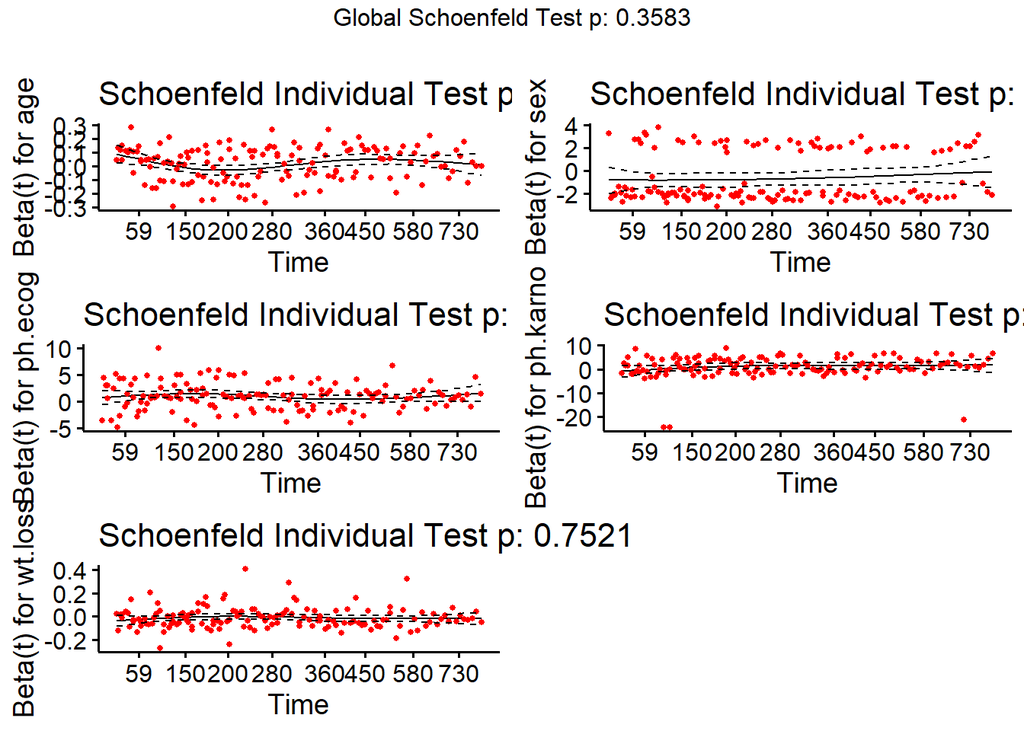

```r
ggcoxzph(test.ph)
```